# STAT 301

Midterm Review

# Statistical Modelling

## 3 models under a common framework

| Model | Response | Distribution | Parameter | Linear |
| --- | --- | --- | --- | --- |
| MLR | continuous | Normal | mean of response | identity |
| Logistic | binary | Bernoulli | probability of S | log-odds |
| Poisson | counts | Poisson | mean count | log |

- mean(house price) = $\beta_0$ + $\beta_1$size + $\beta_2$basementY
- logit(prob. of default) = $\beta_0$ + $\beta_1$balance + $\beta_2$income + $\beta_3$studentY
- log(mean(number of bikes)) = $\beta_0$ + $\beta_1$temperature

**These functions are used to interpret the regression coefficients!!!**

## Interpretation

[output not shown]

## Interpretation: examples

Scroll down to see full content

- Logistic: a dollar increase in balance is associated with
  - an increase in the estimated log odds of default by 0.0055, or
  - an increase in the estimated odds of default by a factor of 1.0055,
  - or an increase in the estimated odds of 0.55%
- Poisson: a Celsius degree increase in temperature is associated with
  - an increase in the estimated log mean number of bikes rented of 0.62, or
  - an increase in the estimated mean number of bikes by a factor of 1.86 ($e^{0.62}$),
  - or an increase in the estimated mean number of bikes of 86% ((1.86-1) $\times$ 100)

## Key words

Scroll down to see full content

- estimate or estimated (these are not population quantities, they depend on the sample)
- associated with (if the data comes from an observational study causation can not be established)
- “by a factor of” or “times” or “percent” if estimated coefficients are exponentiated
- “holding other variables constant at any value” if the model is additive and has more variables, otherwise don’t!
- check units!!

## Additive models vs interactions

- for additive models: coefficients are interpreted holding other variables constant *at any value*
- for models with interactions: interpretations *depend on* levels or values of other variables

**Warning**

Interaction terms **do not** model correlations between covariates!!

We use interactions when **the association** between a covariate and the response **depends on another covariate(s)**

## Example of additive MLR

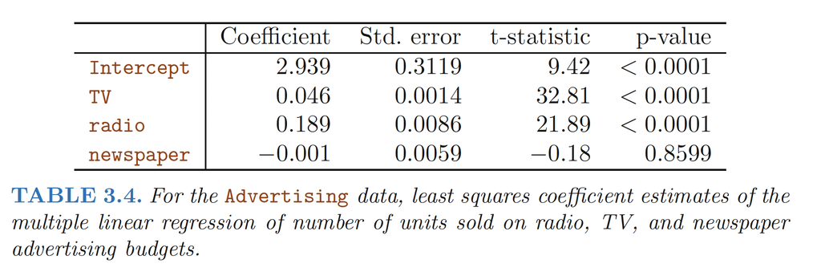

Table from ISLR

## Hypothesis tests and CI

We need the **sampling distribution** (distribution of the estimators of the regression coefficients, $\hat{\beta}_j$)

For the 3 models, we usually use a *Normal approximation of the sampling distribution* (details beyond this course)

- for MLR: we usually need to estimate the variance of the error term ($\sigma$) and the sampling distribution becomes a $t$-student distribution
  - we estimate $\sigma$ using the RMSE, given by `glance()`
- for Logistic and Poisson: the variance of the response depends on their mean so we don’t need to estimate it separately, thus we can use a Normal approximation as the sampling distribution
  - recall that if sometimes we observe overdispersion (or underdispersion)

## Interpretations of tests

Scroll down to see full content

**The null hypothesis**: $H_0: \beta_j = 0$

- check the significance level
- check the alternative hypothesis
- the interpretion depends on the meaning of the coefficient

> We have statistically significant evidence (p-value < .001) that the mean number of fires is positively associated with temperature.
- Remember that we never know what the true population parameters are! At a significance level:
  - we have evidence to reject $H_0$. It doesn’t mean $H_1$ is true!

  or
  - we don’t have enough evidence to reject (we fail to reject) $H_0$. It doesn’t mean $H_0$ is true!

## CIs of coefficients

Recall that once the data is collected, the intervals are not random and we interpret them in terms of **confidence, not probabilities!**

> We are 95% confident that each additional degree in temperature is associated with an increase in the mean number of fires between 5% and 10%.

We can use bootstrapping to compute CIs

## Assumptions and Diagnosis

In `worksheet_03` and `tutorial_03` we used simulations to study the relevance of assumptions made:

- **Normality**: only for MLR, not needed for estimation or large sample apprximations but the linear model will be a good fit if the assumption holds.
- **Homoscedasticity**: only for MLR, the spread (or variance) of the errors in a model is the same across all levels of the covariate(s).
- **Confounding Factor**: a variable related with a covariate and the response, and it can make it look like there’s an association between them, even if there isn’t.
- **Multicollinearity**: correlation between covariates.
- **Independence**: we assume that observations are independent of each other

## Predictions and Residuals

Scroll down to see full content

- Predictions are values of the response computed with the estimated model for fixed values of the covariates:
  - fitted: common name for *in-sample* predictions
- Residuals is the difference between the observed response and the fitted values
- Fitted values and residuals can be computed for the 3 models: MLR, Logistic and Poisson
- **However**: recall that different quantities can be predicted with logistic (log-odds, odds, probabilities) and Poisson (log-counts, counts)
- In Logistic and Poisson, the variance of each observation depends on the covariates (not constant), so residuals are adjusted (e.g., Pearson, deviance)
- See `tutorial_04` and `tutorial_05`